# Predictive Factors Analysis: Investigating the Relationship Between Tumor Characteristics and Cancer Outcome

Abhiroop Yerramilli, Om Pandya, Wasi Alavi

2024-02-29

## Introduction

Cancer, the later it is detected, the tougher it is to treat. Cancer diagnosis and prognosis is dependent on identifying strong potential indicators of cancer severity (Benign or Malignant). This is crucial to aid treatment and patient management. Visual explorations of various features of labelled cancer cell nuclei data sets offer valuable insights into characteristics of tumors and their associations with cancer severity. Using the dataset to examine distributions, highlight insights, trends, and relationships in feature values between benign and malignant cancer cells, will help pinpoint features that explain and exhibit significant variations and can potentially act as reliable predictors of cancer severity. In this report, we employ tabular and visual exploration techniques to identify strong indicators of cancer severity within a labelled cancer cell nuclei dataset, shedding light on features associated with tumor malignancy.

Using the data there are a few questions we want to investigate with our visualizations:

- Which of the listed features are the strongest indicators of cancer severity, based on visual explorations? The dataset has features which refer to different visual characteristics of the cancer cell-nucleus. These features combined with the actual diagnosis, and correlations + visual explorations can show which of these features are the strongest indicators. This analysis will help narrow down the features that can be used to indicate cancer severity.
- Which features show strong correlations with each other, and how might these correlations differ between benign and malignant cancer? We already have the strongest indicators from the above question, and their correlations based on cancer severity. This can be used to further analyze the the differences between these features in benign and malignant severity respectively. This analysis will help us determine what features differentiate benign and malignant severities, and what features are the most correlated amongst themselves.
- How do the size-related features (radius, perimeter, area) correlate with the severity (malignant status) of the tumors? While we have listed all visual features above, there are numerous studies and texts where size-related features are said to be theoretically linked to the severity of the cancer. A few of the studies/texts are linked below. This question aims to explore these assumptions and isolate the features being correlated with the severity. Study/Text #1: https://www.ncbi.nlm.nih.gov/pmc/articles/PMC9722227/ Study/Text #2: https://www.ncbi.nlm.nih.gov/books/NBK9553/ Study/Text #3: https://www.jstage.jst.go.jp/article/bpb/41/4/41_b17-00776/_html/-char/en Study/Text #4: https://karger.com/acy/article/64/6/511/9923/Nuclear-Morphology-and-the-Biology-of-Cancer-Cells

Note: Our response variable here is “diagnosis”.

## Data

The dataset we are using contains characteristics of patients diagnosed with breast cancer. The dataset is under a CC BY-NC-SA 4.0 License. The data is stored in ../data/wdbc.data in tabular form, and the headings are stored in ../data/wdbc.names. First, we read in the data, and find some general information about the data that will help us describe the dataset better:

1. Dimensions
- First we get the dimensions of the dataset.

```
## [1] 569  32
```

- The initial dataset has 569 observations with 32 variables each.
2. Feature Summary
- Next we get the summary of the data.
- Using the summary function, we get the Min value, 1st Quantile, Median, Mean, 3rd Quantile, and Max value of all the features in the dataset.

```
##        id             diagnosis          radius_mean      texture_mean
##  Min.   :     8670   Length:569         Min.   : 6.981   Min.   : 9.71
##  1st Qu.:   869218   Class :character   1st Qu.:11.700   1st Qu.:16.17
##  Median :   906024   Mode  :character   Median :13.370   Median :18.84
##  Mean   : 30371831                      Mean   :14.127   Mean   :19.29
##  3rd Qu.:  8813129                      3rd Qu.:15.780   3rd Qu.:21.80
##  Max.   :911320502                      Max.   :28.110   Max.   :39.28
##  perimeter_mean     area_mean      smoothness_mean   compactness_mean
##  Min.   : 43.79   Min.   : 143.5   Min.   :0.05263   Min.   :0.01938
##  1st Qu.: 75.17   1st Qu.: 420.3   1st Qu.:0.08637   1st Qu.:0.06492
##  Median : 86.24   Median : 551.1   Median :0.09587   Median :0.09263
##  Mean   : 91.97   Mean   : 654.9   Mean   :0.09636   Mean   :0.10434
##  3rd Qu.:104.10   3rd Qu.: 782.7   3rd Qu.:0.10530   3rd Qu.:0.13040
##  Max.   :188.50   Max.   :2501.0   Max.   :0.16340   Max.   :0.34540
##  concavity_mean    concave points_mean symmetry_mean    fractal_dimension_mean
##  Min.   :0.00000   Min.   :0.00000     Min.   :0.1060   Min.   :0.04996
##  1st Qu.:0.02956   1st Qu.:0.02031     1st Qu.:0.1619   1st Qu.:0.05770
##  Median :0.06154   Median :0.03350     Median :0.1792   Median :0.06154
##  Mean   :0.08880   Mean   :0.04892     Mean   :0.1812   Mean   :0.06280
##  3rd Qu.:0.13070   3rd Qu.:0.07400     3rd Qu.:0.1957   3rd Qu.:0.06612
##  Max.   :0.42680   Max.   :0.20120     Max.   :0.3040   Max.   :0.09744
##    radius_se        texture_se      perimeter_se       area_se
##  Min.   :0.1115   Min.   :0.3602   Min.   : 0.757   Min.   :  6.802
##  1st Qu.:0.2324   1st Qu.:0.8339   1st Qu.: 1.606   1st Qu.: 17.850
##  Median :0.3242   Median :1.1080   Median : 2.287   Median : 24.530
##  Mean   :0.4052   Mean   :1.2169   Mean   : 2.866   Mean   : 40.337
##  3rd Qu.:0.4789   3rd Qu.:1.4740   3rd Qu.: 3.357   3rd Qu.: 45.190
##  Max.   :2.8730   Max.   :4.8850   Max.   :21.980   Max.   :542.200
##  smoothness_se      compactness_se      concavity_se     concave points_se
##  Min.   :0.001713   Min.   :0.002252   Min.   :0.00000   Min.   :0.000000
##  1st Qu.:0.005169   1st Qu.:0.013080   1st Qu.:0.01509   1st Qu.:0.007638
##  Median :0.006380   Median :0.020450   Median :0.02589   Median :0.010930
##  Mean   :0.007041   Mean   :0.025478   Mean   :0.03189   Mean   :0.011796
##  3rd Qu.:0.008146   3rd Qu.:0.032450   3rd Qu.:0.04205   3rd Qu.:0.014710
##  Max.   :0.031130   Max.   :0.135400   Max.   :0.39600   Max.   :0.052790
##   symmetry_se       fractal_dimension_se  radius_worst   texture_worst
##  Min.   :0.007882   Min.   :0.0008948    Min.   : 7.93   Min.   :12.02
##  1st Qu.:0.015160   1st Qu.:0.0022480    1st Qu.:13.01   1st Qu.:21.08
##  Median :0.018730   Median :0.0031870    Median :14.97   Median :25.41
##  Mean   :0.020542   Mean   :0.0037949    Mean   :16.27   Mean   :25.68
##  3rd Qu.:0.023480   3rd Qu.:0.0045580    3rd Qu.:18.79   3rd Qu.:29.72
##  Max.   :0.078950   Max.   :0.0298400    Max.   :36.04   Max.   :49.54
##  perimeter_worst    area_worst     smoothness_worst  compactness_worst
##  Min.   : 50.41   Min.   : 185.2   Min.   :0.07117   Min.   :0.02729
##  1st Qu.: 84.11   1st Qu.: 515.3   1st Qu.:0.11660   1st Qu.:0.14720
##  Median : 97.66   Median : 686.5   Median :0.13130   Median :0.21190
##  Mean   :107.26   Mean   : 880.6   Mean   :0.13237   Mean   :0.25427
##  3rd Qu.:125.40   3rd Qu.:1084.0   3rd Qu.:0.14600   3rd Qu.:0.33910
##  Max.   :251.20   Max.   :4254.0   Max.   :0.22260   Max.   :1.05800
##  concavity_worst  concave points_worst symmetry_worst   fractal_dimension_worst
##  Min.   :0.0000   Min.   :0.00000      Min.   :0.1565   Min.   :0.05504
##  1st Qu.:0.1145   1st Qu.:0.06493      1st Qu.:0.2504   1st Qu.:0.07146
##  Median :0.2267   Median :0.09993      Median :0.2822   Median :0.08004
##  Mean   :0.2722   Mean   :0.11461      Mean   :0.2901   Mean   :0.08395
##  3rd Qu.:0.3829   3rd Qu.:0.16140      3rd Qu.:0.3179   3rd Qu.:0.09208
##  Max.   :1.2520   Max.   :0.29100      Max.   :0.6638   Max.   :0.20750
```

- After getting the summary, we can give more information about the features to add additional context.
- The dataset has 12 main features. The first 2 main features are:
- id (numeric): unique ID of each patient
- diagnosis (character): cancer severity. Possible values are B (Benign) and M (Malignant). This is our target variable. None of these 2 features have any units, and both have one column each in the dataset.
- There are 10 other features. These features describe the visual characteristics of the cancel cell nuclei, and each feature has 3 columns for the mean value, standard error, and the worst value out of all the cancer cells considered per patient.
- radius (numeric,numeric,numeric): The radius of the cancer cell nuclei
- texture (numeric,numeric,numeric): The texture of the cancer cell nuclei. This is a calculation of deviation of gray-scale values.
- perimeter (numeric,numeric,numeric): The perimeter of the cancer cell nuclei
- area (numeric,numeric,numeric): The area of the cancer cell nuclei
- smoothness (numeric,numeric,numeric): The smoothness of the cancer cell nuclei. This is a calculation of the local variation in radius.
- concavity (numeric,numeric,numeric): The concavity of the cancer cell nuclei. Formula here is perimeter^2 / area - 1.0
- compactness (numeric,numeric,numeric): The compactness of the cancer cell nuclei. This is the severity of the concave portions of the contour.
- symmetery (numeric,numeric,numeric): The symmetery of the cancer cell nuclei.
- fractal_dimension (numeric,numeric,numeric): “coastline approximation” - 1. NOTE: Coastline approximation is a method used to estimate the fractal dimension of an irregularly shaped body by comparing measured length with different scales. We have reached out to the contributors to get more information on the units but we have not heard back. The papers do not list the units.
3. Target Variable
- Before delving into analysis, we want to have a look at the target variable here (“diagnosis”).
- We can get a table with the counts, and a bar plot to get the distribution of the target variable.

| diagnosis | n |
| --- | --- |
| B | 357 |
| M | 212 |

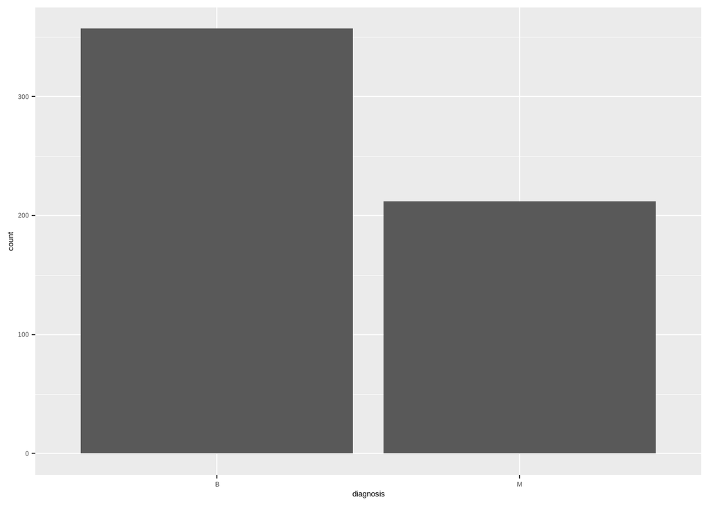

We know that B refers to Benign and M refers to Malignant. This means that: - 62.7% of the dataset is on benign cancer cells. - 37.3% of the dataset is on malignant cancer cells.

- Another key reason for choosing diagnosis as the target variable is because that column has no missing values, and delivers the most information based on the questions we wish to answer.
4. Data Collection and Ownership:
1. Title: Wisconsin Diagnostic Breast Cancer (WDBC)
2. Source Information:
- Creators:
- Dr. William H. Wolberg, General Surgery Dept., University of Wisconsin, Clinical Sciences Center, Madison, WI 53792 wolberg@eagle.surgery.wisc.edu
- W. Nick Street, Computer Sciences Dept., University of Wisconsin, 1210 West Dayton St., Madison, WI 53706 street@cs.wisc.edu 608-262-6619
- Olvi L. Mangasarian, Computer Sciences Dept., University of Wisconsin, 1210 West Dayton St., Madison, WI 53706 olvi@cs.wisc.edu
- Donor: Nick Street
- Date: November 1995
3. Collection Method
- Features are computed from a digitized image of a fine needle aspirate (FNA) of a breast mass. They describe characteristics of the cell nuclei present in the image. A few of the images can be found at http://www.cs.wisc.edu/~street/images/
- Separating plane described above was obtained using Multisurface Method-Tree (MSM-T) [K. P. Bennett, “Decision Tree Construction Via Linear Programming.” Proceedings of the 4th Midwest Artificial Intelligence and Cognitive Science Society, pp. 97-101, 1992], a classification method which uses linear programming to construct a decision tree. Relevant features were selected using an exhaustive search in the space of 1-4 features and 1-3 separating planes.
- The actual linear program used to obtain the separating plane in the 3-dimensional space is that described in: [K. P. Bennett and O. L. Mangasarian: “Robust Linear Programming Discrimination of Two Linearly Inseparable Sets”, Optimization Methods and Software 1, 1992, 23-34].

## Exploratory analysis

Through this exploratory analysis, we aim to uncover key insights than inform subsequent analysis, highlight trends, and bring up relationships between different features. This lays the groundwork for preprocessing, assumptions, and visualizations.

1. Data Preprocessing Before introductory assumptions and exploratory analysis, we need to preprocess our data. The main issues and solutions will be outlined below:
1. The target variable is not a numeric variable.
- The target variable here, diagnosis, is a character feature with 2 possible values : “B” (Benign) and “M” (Malignant).
- The nature of this variable, character, limits our abilities to compute correlations, draw visualization, make models, etc. This would be an issue moving forward.
- A potential solution would be to convert the target variable into 1 and 2 instead of “B” and “M” respectively.
- Another reason for this conversion is additional help with making linear models later in this section.
- This will convert the target variable into a numeric discrete variable and make it simpler to analyze and visualize relationships, trends, and insights.

```
##   diagnosis   n
## 1         1 357
## 2         2 212
```

2. Missing Values
- Having missing values is a common issue with datasets.
- We can do a check using the diagnose function to check missing values in our dataset

```
## # A tibble: 32 × 6
##    variables        types missing_count missing_percent unique_count unique_rate
##    <chr>            <chr>         <int>           <dbl>        <int>       <dbl>
##  1 id               inte…             0               0          569     1
##  2 diagnosis        nume…             0               0            2     0.00351
##  3 radius_mean      nume…             0               0          456     0.801
##  4 texture_mean     nume…             0               0          479     0.842
##  5 perimeter_mean   nume…             0               0          522     0.917
##  6 area_mean        nume…             0               0          539     0.947
##  7 smoothness_mean  nume…             0               0          474     0.833
##  8 compactness_mean nume…             0               0          537     0.944
##  9 concavity_mean   nume…             0               0          537     0.944
## 10 concave points_… nume…             0               0          542     0.953
## # ℹ 22 more rows
```

- However, in our dataset, as outlined in the general diagnosis from the previous section, we do not have any missing values.
- The missing percent for all the features is 0%, hence no fixing/solutions are required.
3. Outliers
- We consider an outlier ratio of 5% of higher to be significant.
- This is based on the fact that if 5% of the values are outliers, the intervals for non-outlier values is 95% of the total range.
- We consider this to be a good interval.
- First we get the outliers of all the features

```
##                  variables outliers_cnt outliers_ratio outliers_mean
## 1                       id           81     14.2355009  1.982447e+08
## 2                diagnosis            0      0.0000000           NaN
## 3              radius_mean           14      2.4604569  2.451643e+01
## 4             texture_mean            7      1.2302285  3.308286e+01
## 5           perimeter_mean           13      2.2847100  1.661077e+02
## 6                area_mean           25      4.3936731  1.670520e+03
## 7          smoothness_mean            6      1.0544815  1.300217e-01
## 8         compactness_mean           16      2.8119508  2.684250e-01
## 9           concavity_mean           18      3.1634446  3.412889e-01
## 10     concave points_mean           10      1.7574692  1.754100e-01
## 11           symmetry_mean           15      2.6362039  2.536067e-01
## 12  fractal_dimension_mean           15      2.6362039  8.608533e-02
## 13               radius_se           38      6.6783831  1.155216e+00
## 14              texture_se           20      3.5149385  2.968900e+00
```

[output cut: 51 more lines]

- Then we get features with outliers above 5% (here the outliers_ratio is the percentage*100).

```
##       variables outliers_cnt outliers_ratio outliers_mean    with_mean
## 1            id           81      14.235501  1.982447e+08 3.037183e+07
## 2     radius_se           38       6.678383  1.155216e+00 4.051721e-01
## 3  perimeter_se           38       6.678383  8.483868e+00 2.866059e+00
## 4       area_se           65      11.423550  1.332746e+02 4.033708e+01
## 5 smoothness_se           30       5.272408  1.574633e-02 7.040979e-03
## 6    area_worst           35       6.151142  2.435743e+03 8.805831e+02
##   without_mean
## 1 2.507687e+06
## 2 3.514966e-01
## 3 2.464031e+00
## 4 2.835109e+01
## 5 6.556451e-03
## 6 7.786532e+02
```

- We will not be using id for visualizations. This will be explained more in the introductory assumptions below.
- To treat these first we want to check the correlations of these features with the target variable.

```
##                      [,1]
## radius_se      0.56713382
## perimeter_se   0.55614070
## area_se        0.54823594
## smoothness_se -0.06701601
## area_worst     0.73382503
## diagnosis      1.00000000
```

- We can see that smoothness_se has a correlation of < |+-0.2|, which makes the correlation insignificant.
- For this feature, we want to remove it due to the number of outliers and its low correlation.
- Looking at the new data, and the outliers, we do not want to manipulate values any further from the dataset. There are a few reasons for this:
- We see most of these more than 5% ratio outliers are close to 5%. This does affect the data quality but it still can be considered.
- The outliers here are related to other features from the dataset. For instance area_se is related to area_mean. This means that manipulating these values would impact the relationship between this feature and the related feature, thereby affecting the results of the original study.
- Due to the small size of the dataset, and the citations related to it, it is assumed that the outliers capture valuable information. These do reduce statistic significance of the variable to an extent. However, these outliers have been considered legitimate anomalies and hence we are not manipulating them.
4. Variable names
- Three variables in the table have names which have spaces. These cause issues with addressing, and using these features for plotting.
- These features are “concave points_mean”, “concave points_se” , and “concave points_worst”
- Not being able to use these features cause issues with highlighting trends and relationships.
- We removed the spaces and put an _ instead. These features are now “concave_points_mean”, “concave_points_se” , and “concave_points_worst”
- Here is an output of the column names to verify this:

```
##  [1] "id"                      "diagnosis"
##  [3] "radius_mean"             "texture_mean"
##  [5] "perimeter_mean"          "area_mean"
##  [7] "smoothness_mean"         "compactness_mean"
##  [9] "concavity_mean"          "concave_points_mean"
## [11] "symmetry_mean"           "fractal_dimension_mean"
## [13] "radius_se"               "texture_se"
## [15] "perimeter_se"            "area_se"
## [17] "compactness_se"          "concavity_se"
## [19] "concave_points_se"       "symmetry_se"
## [21] "fractal_dimension_se"    "radius_worst"
## [23] "texture_worst"           "perimeter_worst"
## [25] "area_worst"              "smoothness_worst"
## [27] "compactness_worst"       "concavity_worst"
## [29] "concave_points_worst"    "symmetry_worst"
## [31] "fractal_dimension_worst"
```

2. Introductory Assumptions Before starting with visualizations, we note down a few assumptions made on known and learnt knowledge. These will be explored first and conclusions will be recorded
1. The id the patient would not affect the cancer severity in any way.
- The .names file, which contains information about the data, does not mention that the the id is assigned to the patient based on their cancer cells, so going by the general rule in medical institutions where id’s are assigned at random, the id might not be related to the cancer cell’s characteristics.
- To explore this, we can find correlations between the id and all the other features.

```
##                                  [,1]
## id                       1.0000000000
## diagnosis                0.0397685096
## radius_mean              0.0746264697
## texture_mean             0.0997698912
## perimeter_mean           0.0731594119
## area_mean                0.0968928233
## smoothness_mean         -0.0129681975
## compactness_mean         0.0000957011
## concavity_mean           0.0500799532
## concave_points_mean      0.0441580956
## symmetry_mean           -0.0221140609
## fractal_dimension_mean  -0.0525114476
## radius_se                0.1430475814
## texture_se              -0.0075261904
## perimeter_se             0.1373310660
## area_se                  0.1777419152
## compactness_se           0.0339609721
## concavity_se             0.0552393174
## concave_points_se        0.0787680711
## symmetry_se             -0.0173062948
## fractal_dimension_se     0.0257253243
## radius_worst             0.0824053373
## texture_worst            0.0647195454
## perimeter_worst          0.0799858731
## area_worst               0.1071865233
## smoothness_worst         0.0103380343
## compactness_worst       -0.0029680998
## concavity_worst          0.0232027439
## concave_points_worst     0.0351735794
## symmetry_worst          -0.0442242529
## fractal_dimension_worst -0.0298656360
```

- We can see that based on the above table of correlations, ID has very low positive or negative correlations with any features except itself.
- It also has extremely low correlation with the target variable diagnosis.
- We believe based on this, our assumption holds true, and we will not consider id in our visualizations and analysis moving forward.
2. Going by this paper: https://www.bmj.com/about-bmj/resources-readers/publications/statistics-square-one/11-correlation-and-regression we draw a few rules:
- 0 to +- 0.199 is insignificant correlation.
- 0.2 to +- 0.399 is weak correlation.
- 0.4 to +- 0.599 is moderate correlation.
- 0.6 to +- 0.799 is strong correlation.
- 0.8 to +- 1 is very strong correlation. This a combination of a rule and assumption. This will help us answer our questions. Especially interpreting correlations and deciding on variables to choose.
3. Exploratory Visualizations (after preprocessing, and based on assumptions above)
1. Correlations between diagnosis and other features
- First a mapping between correlations and other features would help us pick the most significant correlated features, and draw insights.
- We used the pearson coefficient here, while keeping in mind that correlation does not necessarily mean causation.

```
##                                 [,1]
## radius_mean              0.730028511
## radius_se                0.567133821
## radius_worst             0.776453779
## texture_mean             0.415185300
## texture_se              -0.008303333
## texture_worst            0.456902821
## perimeter_mean           0.742635530
## perimeter_se             0.556140703
## perimeter_worst          0.782914137
## area_mean                0.708983837
## area_se                  0.548235940
## area_worst               0.733825035
## smoothness_mean          0.358559965
## smoothness_worst         0.421464861
## compactness_mean         0.596533678
## compactness_se           0.292999244
## compactness_worst        0.590998238
## concavity_mean           0.696359707
## concavity_se             0.253729766
## concavity_worst          0.659610210
## concave_points_mean      0.776613840
## concave_points_se        0.408042333
## concave_points_worst     0.793566017
## symmetry_mean            0.330498554
## symmetry_se             -0.006521756
## symmetry_worst           0.416294311
## fractal_dimension_mean  -0.012837603
## fractal_dimension_se     0.077972417
## fractal_dimension_worst  0.323872189
```

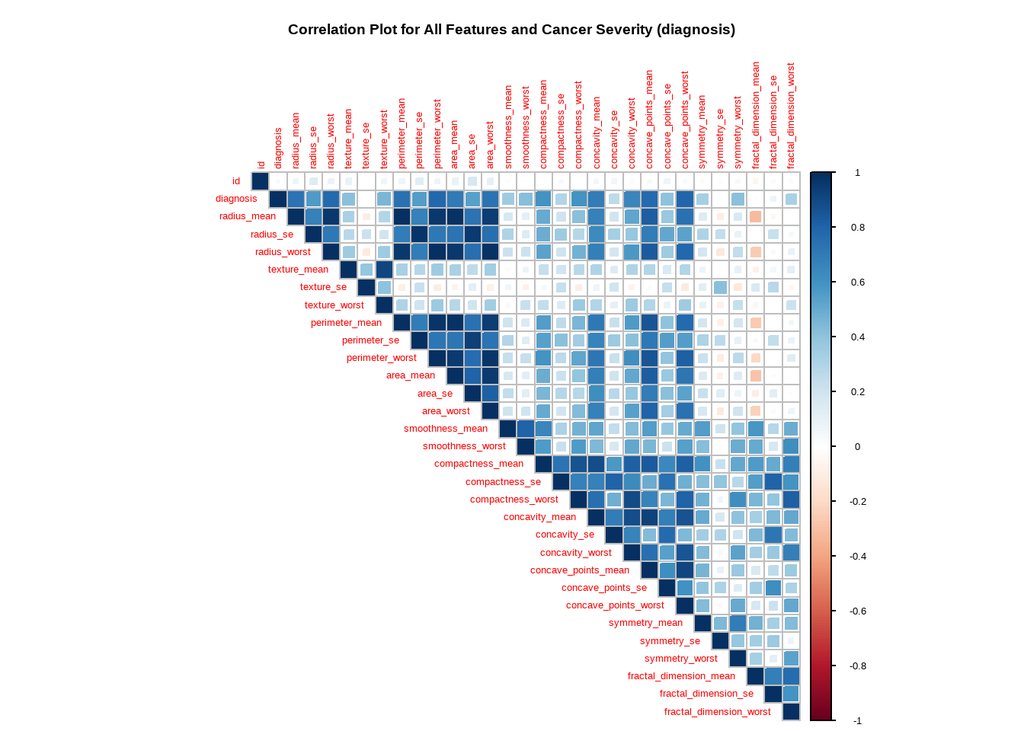

2. Correlation between diagnosis and size-related features (radius, perimeter, area)
- 3 size-related features have been defined in one of the questions based on multiple studies and papers we referred to.
- Each of these 3 size-related features have 3 related features (mean, se, worst) respectively.
- This gives us a total of 9 features to correlate with diagnosis.

```
##                      [,1]
## radius_mean     0.7300285
## radius_se       0.5671338
## radius_worst    0.7764538
## perimeter_mean  0.7426355
## perimeter_se    0.5561407
## perimeter_worst 0.7829141
## area_mean       0.7089838
## area_se         0.5482359
## area_worst      0.7338250
```

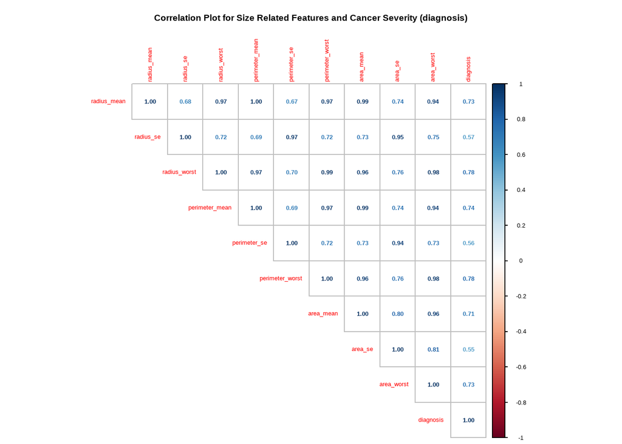

3. Scatterplots to investigate relationships between different features, for additional insights, differentiated by cancer severity.
- First we make a correlation matrix to get how related the features are.
- NOTE: We are only considering the features that were found to be significant in the correlation matrix from (iii)(a).

  |  | radius_mean | texture_mean | perimeter_mean | area_mean | compactness_mean | concavity_mean | concave_points_mean | radius_se | perimeter_se | area_se | concave_points_se | radius_worst | texture_worst | perimeter_worst | area_worst | smoothness_worst | compactness_worst | concavity_worst | concave_points_worst | symmetry_worst |
  | --- | --- | --- | --- | --- | --- | --- | --- | --- | --- | --- | --- | --- | --- | --- | --- | --- | --- | --- | --- | --- |
  | radius_mean | 1.0000000 | 0.3237819 | 0.9978553 | 0.9873572 | 0.5061236 | 0.6767636 | 0.8225285 | 0.6790904 | 0.6741716 | 0.7358637 | 0.3761690 | 0.9695390 | 0.2970076 | 0.9651365 | 0.9410825 | 0.1196161 | 0.4134628 | 0.5269115 | 0.7442142 | 0.1639533 |
  | texture_mean | 0.3237819 | 1.0000000 | 0.3295331 | 0.3210857 | 0.2367022 | 0.3024178 | 0.2934641 | 0.2758687 | 0.2816731 | 0.2598450 | 0.1638510 | 0.3525729 | 0.9120446 | 0.3580396 | 0.3435459 | 0.0775034 | 0.2778296 | 0.3010252 | 0.2953158 | 0.1050079 |
  | perimeter_mean | 0.9978553 | 0.3295331 | 1.0000000 | 0.9865068 | 0.5569362 | 0.7161357 | 0.8509770 | 0.6917650 | 0.6931349 | 0.7449827 | 0.4072169 | 0.9694764 | 0.3030384 | 0.9703869 | 0.9415498 | 0.1505494 | 0.4557742 | 0.5638793 | 0.7712408 | 0.1891150 |
  | area_mean | 0.9873572 | 0.3210857 | 0.9865068 | 1.0000000 | 0.4985017 | 0.6859828 | 0.8232689 | 0.7325622 | 0.7266283 | 0.8000859 | 0.3723203 | 0.9627461 | 0.2874886 | 0.9591196 | 0.9592133 | 0.1235229 | 0.3904103 | 0.5126059 | 0.7220166 | 0.1435699 |
  | compactness_mean | 0.5061236 | 0.2367022 | 0.5569362 | 0.4985017 | 1.0000000 | 0.8831207 | 0.8311350 | 0.4974734 | 0.5489053 | 0.4556529 | 0.6422619 | 0.5353154 | 0.2481328 | 0.5902104 | 0.5096038 | 0.5655412 | 0.8658090 | 0.8162752 | 0.8155732 | 0.5102234 |
  | concavity_mean | 0.6767636 | 0.3024178 | 0.7161357 | 0.6859828 | 0.8831207 | 1.0000000 | 0.9213910 | 0.6319248 | 0.6603908 | 0.6174268 | 0.6832599 | 0.6882364 | 0.2998789 | 0.7295649 | 0.6759872 | 0.4488220 | 0.7549680 | 0.8841026 | 0.8613230 | 0.4094641 |
  | concave_points_mean | 0.8225285 | 0.2934641 | 0.8509770 | 0.8232689 | 0.8311350 | 0.9213910 | 1.0000000 | 0.6980498 | 0.7106499 | 0.6902985 | 0.6156341 | 0.8303176 | 0.2927517 | 0.8559231 | 0.8096296 | 0.4527531 | 0.6674537 | 0.7523995 | 0.9101553 | 0.3757441 |
  | radius_se | 0.6790904 | 0.2758687 | 0.6917650 | 0.7325622 | 0.4974734 | 0.6319248 | 0.6980498 | 1.0000000 | 0.9727937 | 0.9518301 | 0.5133464 | 0.7150652 | 0.1947986 | 0.7196838 | 0.7515485 | 0.1419186 | 0.2871032 | 0.3805846 | 0.5310623 | 0.0945428 |
  | perimeter_se | 0.6741716 | 0.2816731 | 0.6931349 | 0.7266283 | 0.5489053 | 0.6603908 | 0.7106499 | 0.9727937 | 1.0000000 | 0.9376554 | 0.5562641 | 0.6972006 | 0.2003709 | 0.7210313 | 0.7307130 | 0.1300544 | 0.3419194 | 0.4188988 | 0.5548972 | 0.1099304 |
  | area_se | 0.7358637 | 0.2598450 | 0.7449827 | 0.8000859 | 0.4556529 | 0.6174268 | 0.6902985 | 0.9518301 | 0.9376554 | 1.0000000 | 0.4157296 | 0.7573732 | 0.1964966 | 0.7612126 | 0.8114080 | 0.1253894 | 0.2832565 | 0.3851001 | 0.5381663 | 0.0741263 |
  | concave_points_se | 0.3761690 | 0.1638510 | 0.4072169 | 0.3723203 | 0.6422619 | 0.6832599 | 0.6156341 | 0.5133464 | 0.5562641 | 0.4157296 | 1.0000000 | 0.3581267 | 0.0867412 | 0.3949993 | 0.3422712 | 0.2153506 | 0.4528884 | 0.5495924 | 0.6024496 | 0.1431157 |
  | radius_worst | 0.9695390 | 0.3525729 | 0.9694764 | 0.9627461 | 0.5353154 | 0.6882364 | 0.8303176 | 0.7150652 | 0.6972006 | 0.7573732 | 0.3581267 | 1.0000000 | 0.3599208 | 0.9937079 | 0.9840146 | 0.2165744 | 0.4758200 | 0.5739747 | 0.7874239 | 0.2435292 |
  | texture_worst | 0.2970076 | 0.9120446 | 0.3030384 | 0.2874886 | 0.2481328 | 0.2998789 | 0.2927517 | 0.1947986 | 0.2003709 | 0.1964966 | 0.0867412 | 0.3599208 | 1.0000000 | 0.3650982 | 0.3458423 | 0.2254294 | 0.3608323 | 0.3683656 | 0.3597546 | 0.2330275 |
  | perimeter_worst | 0.9651365 | 0.3580396 | 0.9703869 | 0.9591196 | 0.5902104 | 0.7295649 | 0.8559231 | 0.7196838 | 0.7210313 | 0.7612126 | 0.3949993 | 0.9937079 | 0.3650982 | 1.0000000 | 0.9775781 | 0.2367746 | 0.5294077 | 0.6183441 | 0.8163221 | 0.2694928 |
  | area_worst | 0.9410825 | 0.3435459 | 0.9415498 | 0.9592133 | 0.5096038 | 0.6759872 | 0.8096296 | 0.7515485 | 0.7307130 | 0.8114080 | 0.3422712 | 0.9840146 | 0.3458423 | 0.9775781 | 1.0000000 | 0.2091453 | 0.4382963 | 0.5433305 | 0.7474188 | 0.2091455 |
  | smoothness_worst | 0.1196161 | 0.0775034 | 0.1505494 | 0.1235229 | 0.5655412 | 0.4488220 | 0.4527531 | 0.1419186 | 0.1300544 | 0.1253894 | 0.2153506 | 0.2165744 | 0.2254294 | 0.2367746 | 0.2091453 | 1.0000000 | 0.5681865 | 0.5185233 | 0.5476909 | 0.4938383 |
  | compactness_worst | 0.4134628 | 0.2778296 | 0.4557742 | 0.3904103 | 0.8658090 | 0.7549680 | 0.6674537 | 0.2871032 | 0.3419194 | 0.2832565 | 0.4528884 | 0.4758200 | 0.3608323 | 0.5294077 | 0.4382963 | 0.5681865 | 1.0000000 | 0.8922609 | 0.8010804 | 0.6144405 |
  | concavity_worst | 0.5269115 | 0.3010252 | 0.5638793 | 0.5126059 | 0.8162752 | 0.8841026 | 0.7523995 | 0.3805846 | 0.4188988 | 0.3851001 | 0.5495924 | 0.5739747 | 0.3683656 | 0.6183441 | 0.5433305 | 0.5185233 | 0.8922609 | 1.0000000 | 0.8554339 | 0.5325197 |
  | concave_points_worst | 0.7442142 | 0.2953158 | 0.7712408 | 0.7220166 | 0.8155732 | 0.8613230 | 0.9101553 | 0.5310623 | 0.5548972 | 0.5381663 | 0.6024496 | 0.7874239 | 0.3597546 | 0.8163221 | 0.7474188 | 0.5476909 | 0.8010804 | 0.8554339 | 1.0000000 | 0.5025285 |
  | symmetry_worst | 0.1639533 | 0.1050079 | 0.1891150 | 0.1435699 | 0.5102234 | 0.4094641 | 0.3757441 | 0.0945428 | 0.1099304 | 0.0741263 | 0.1431157 | 0.2435292 | 0.2330275 | 0.2694928 | 0.2091455 | 0.4938383 | 0.6144405 | 0.5325197 | 0.5025285 | 1.0000000 |

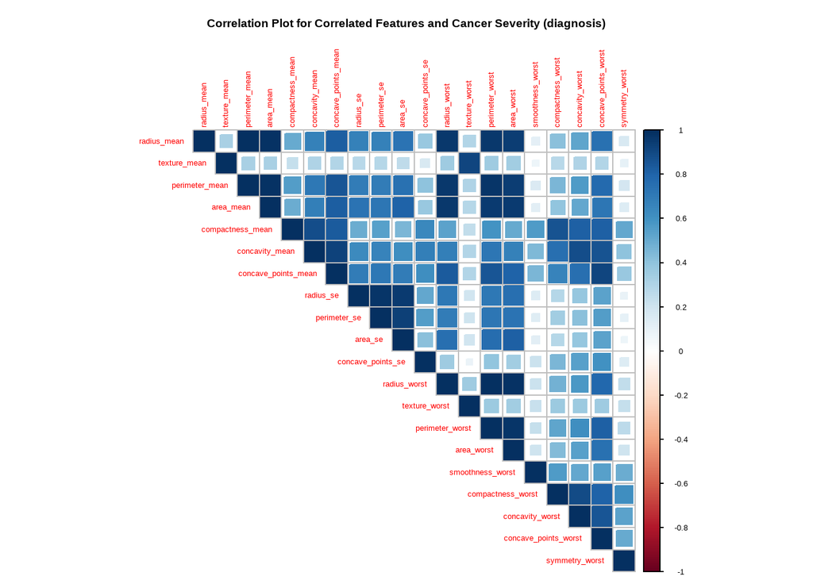

- For all the below scatterplots, we are going to color the points based on the diagnosis (Benign or Malignant). * Texture vs Radius of the cancer cell nuclei. - This visualization would help understand how texture of cell nuclei varies concerning the radius.

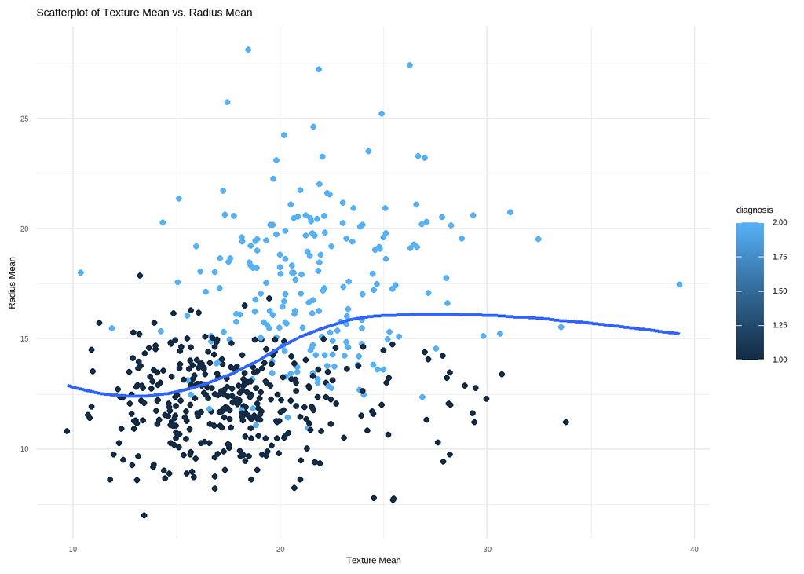

* Compactness vs Concavity - This visualization would help understand how the compactness of the cancer cell nuclei is related to how well concave the cells are.

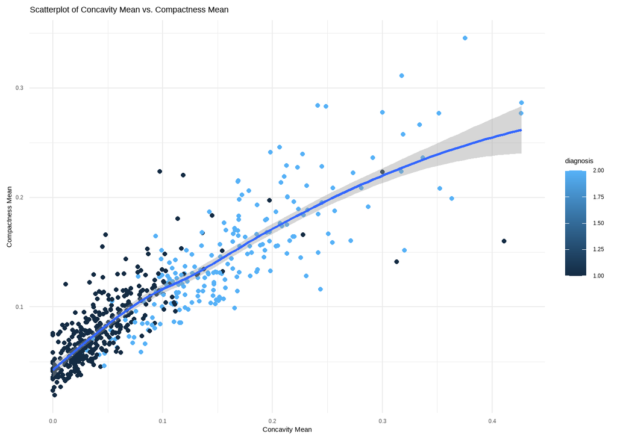

* Perimeter vs Texture - This visualization would help understand how the texture of cell nuclei varies concerning the perimeter.

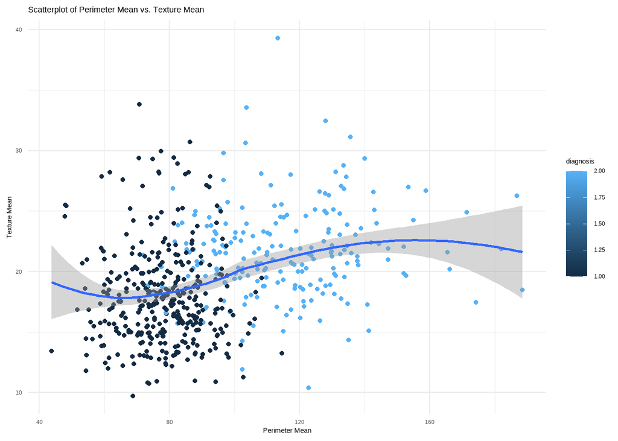

* Texture vs Compactness - This visualization would help understand how the texture of cell nuclei varies concerning the compactness of the cell nuclei.

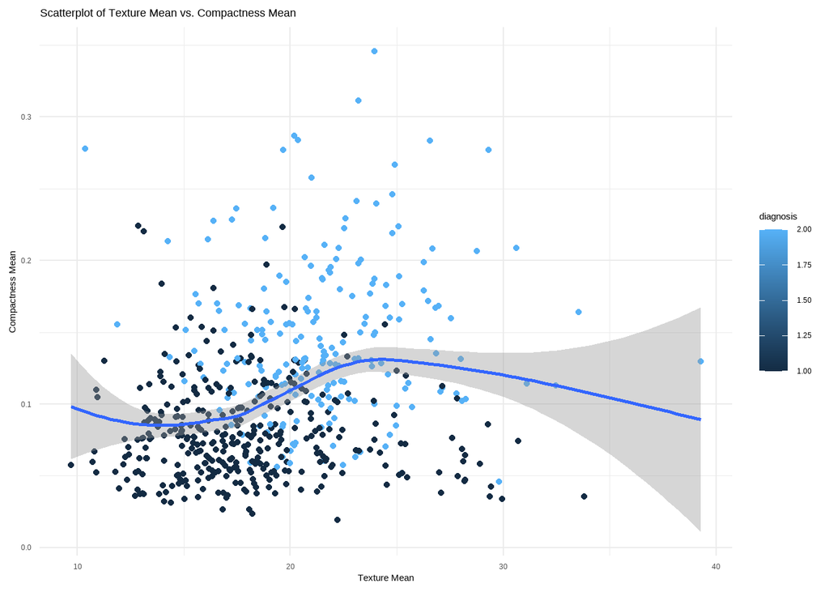

* Radius vs Concavity - This visualization would help understand how the radius of cell nuclei varies concerning the concavity of the cell nuclei.

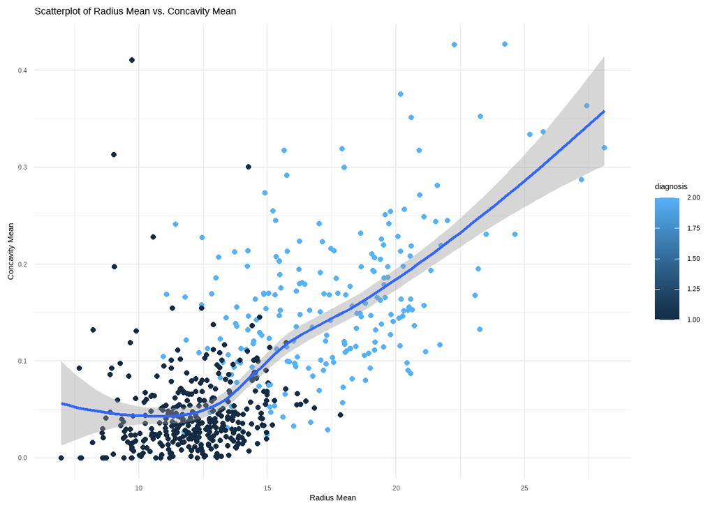

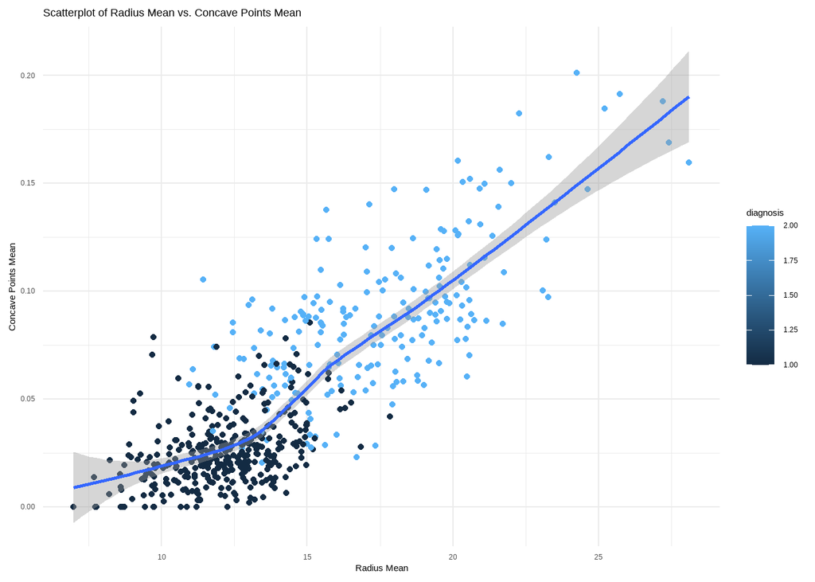

4. Linear Models
- Now we want to construct some linear models based on the most correlated features to get a better idea of the the feature indicators.
- But first we need two more datasets, one with only benign data nad one with only malignant data. These will help determine diagnosis based indicators.
- Now we can build 3 linear models.
- Linear Model 1
- This model shows the significant features based on the entire dataset, with all diagnosis data.
- We make a model using lm, and get the summary

```
##
## Call:
## lm(formula = diagnosis ~ radius_mean + texture_mean + perimeter_mean +
##     area_mean + compactness_mean + concavity_mean + concave_points_mean +
##     radius_se + perimeter_se + area_se + concave_points_se +
##     radius_worst + texture_worst + perimeter_worst + area_worst +
##     smoothness_worst + compactness_worst + concavity_worst +
##     concave_points_worst + symmetry_worst, data = data)
##
## Residuals:
##      Min       1Q   Median       3Q      Max
## -0.63597 -0.17702 -0.02989  0.14105  0.79040
##
## Coefficients:
##                        Estimate Std. Error t value Pr(>|t|)
## (Intercept)          -0.6795018  0.2503159  -2.715 0.006845 **
## radius_mean          -0.3061993  0.1680079  -1.823 0.068920 .
## texture_mean          0.0099920  0.0068267   1.464 0.143859
## perimeter_mean        0.0377532  0.0240975   1.567 0.117766
## area_mean             0.0003247  0.0005014   0.648 0.517423
## compactness_mean     -4.4826813  1.0421328  -4.301 2.01e-05 ***
## concavity_mean       -0.1795604  0.8796398  -0.204 0.838328
## concave_points_mean   4.8487894  1.7106010   2.835 0.004758 **
## radius_se             0.4547537  0.2923074   1.556 0.120348
## perimeter_se          0.0015118  0.0386751   0.039 0.968834
## area_se              -0.0017831  0.0013021  -1.369 0.171436
## concave_points_se     2.2435654  3.7165001   0.604 0.546308
## radius_worst          0.1931639  0.0550547   3.509 0.000488 ***
## texture_worst         0.0037188  0.0049869   0.746 0.456162
## perimeter_worst      -0.0061060  0.0057917  -1.054 0.292224
## area_worst           -0.0008838  0.0003051  -2.897 0.003922 **
## smoothness_worst      2.7872138  0.7487940   3.722 0.000218 ***
## compactness_worst     0.5467628  0.2630907   2.078 0.038153 *
## concavity_worst       0.1766331  0.2494428   0.708 0.479178
## concave_points_worst  0.4504545  0.8285106   0.544 0.586875
## symmetry_worst        0.6586064  0.2263430   2.910 0.003764 **
## ---
## Signif. codes:  0 '***' 0.001 '**' 0.01 '*' 0.05 '.' 0.1 ' ' 1
##
## Residual standard error: 0.2394 on 548 degrees of freedom
## Multiple R-squared:  0.7638, Adjusted R-squared:  0.7552
## F-statistic:  88.6 on 20 and 548 DF,  p-value: < 2.2e-16
```

- Linear Model 2
- This model shows the significant features based on the entire dataset, with benign data.
- We make a model using lm, and get the summary

```
##
## Call:
## lm(formula = diagnosis ~ radius_mean + texture_mean + perimeter_mean +
##     area_mean + compactness_mean + concavity_mean + concave_points_mean +
##     radius_se + perimeter_se + area_se + concave_points_se +
##     radius_worst + texture_worst + perimeter_worst + area_worst +
##     smoothness_worst + compactness_worst + concavity_worst +
##     concave_points_worst + symmetry_worst, data = benign_data)
##
## Residuals:
##        Min         1Q     Median         3Q        Max
## -2.902e-15 -7.170e-16 -1.910e-16  2.820e-16  7.692e-14
##
## Coefficients:
##                        Estimate Std. Error    t value Pr(>|t|)
## (Intercept)           1.000e+00  9.373e-15  1.067e+14   <2e-16 ***
## radius_mean           1.684e-15  6.696e-15  2.520e-01    0.802
## texture_mean          4.242e-17  1.698e-16  2.500e-01    0.803
## perimeter_mean        2.896e-16  8.847e-16  3.270e-01    0.744
## area_mean            -5.305e-17  4.332e-17 -1.225e+00    0.222
## compactness_mean     -1.297e-14  2.929e-14 -4.430e-01    0.658
## concavity_mean       -6.269e-15  2.703e-14 -2.320e-01    0.817
## concave_points_mean   3.756e-14  5.222e-14  7.190e-01    0.472
## radius_se             2.459e-15  1.422e-14  1.730e-01    0.863
## perimeter_se          3.165e-16  1.217e-15  2.600e-01    0.795
## area_se              -6.494e-17  1.608e-16 -4.040e-01    0.687
## concave_points_se    -1.408e-14  1.121e-13 -1.260e-01    0.900
## radius_worst         -3.917e-15  3.025e-15 -1.295e+00    0.196
## texture_worst        -4.730e-17  1.240e-16 -3.810e-01    0.703
## perimeter_worst       8.999e-17  2.469e-16  3.640e-01    0.716
## area_worst            4.602e-17  3.465e-17  1.328e+00    0.185
## smoothness_worst      1.204e-14  1.892e-14  6.360e-01    0.525
## compactness_worst    -1.095e-14  9.926e-15 -1.103e+00    0.271
## concavity_worst       4.078e-15  8.138e-15  5.010e-01    0.617
## concave_points_worst  7.640e-15  2.650e-14  2.880e-01    0.773
## symmetry_worst        3.853e-15  6.513e-15  5.920e-01    0.555
## ---
## Signif. codes:  0 '***' 0.001 '**' 0.01 '*' 0.05 '.' 0.1 ' ' 1
##
## Residual standard error: 4.272e-15 on 336 degrees of freedom
## Multiple R-squared:  0.5001, Adjusted R-squared:  0.4703
## F-statistic: 16.81 on 20 and 336 DF,  p-value: < 2.2e-16
```

- Linear Model 3
- This model shows the significant features based on the entire dataset, with malignant data.
- We make a model using lm, and get the summary

```
##
## Call:
## lm(formula = diagnosis ~ radius_mean + texture_mean + perimeter_mean +
##     area_mean + compactness_mean + concavity_mean + concave_points_mean +
##     radius_se + perimeter_se + area_se + concave_points_se +
##     radius_worst + texture_worst + perimeter_worst + area_worst +
##     smoothness_worst + compactness_worst + concavity_worst +
##     concave_points_worst + symmetry_worst, data = malignant_data)
##
## Residuals:
##        Min         1Q     Median         3Q        Max
## -9.864e-15 -1.820e-15 -3.750e-16  1.388e-15  7.699e-14
##
## Coefficients:
##                        Estimate Std. Error    t value Pr(>|t|)
## (Intercept)           2.000e+00  1.493e-14  1.340e+14  < 2e-16 ***
## radius_mean           1.771e-14  5.690e-15  3.112e+00  0.00214 **
## texture_mean         -3.439e-16  2.758e-16 -1.247e+00  0.21387
## perimeter_mean       -2.133e-15  8.475e-16 -2.517e+00  0.01266 *
## area_mean            -4.388e-17  1.889e-17 -2.323e+00  0.02122 *
## compactness_mean      7.267e-14  4.638e-14  1.567e+00  0.11881
## concavity_mean        3.276e-14  3.560e-14  9.200e-01  0.35866
## concave_points_mean  -4.524e-15  6.329e-14 -7.100e-02  0.94309
## radius_se            -1.148e-14  1.030e-14 -1.114e+00  0.26657
## perimeter_se          1.179e-15  1.373e-15  8.590e-01  0.39148
## area_se               5.226e-17  4.735e-17  1.104e+00  0.27107
## concave_points_se    -2.409e-13  1.529e-13 -1.576e+00  0.11661
## radius_worst         -3.200e-15  1.758e-15 -1.821e+00  0.07021 .
## texture_worst        -1.516e-17  2.041e-16 -7.400e-02  0.94086
## perimeter_worst       3.901e-16  1.734e-16  2.249e+00  0.02563 *
## area_worst            9.063e-18  9.745e-18  9.300e-01  0.35356
## smoothness_worst     -1.660e-14  3.463e-14 -4.790e-01  0.63231
## compactness_worst    -4.808e-15  9.272e-15 -5.190e-01  0.60464
## concavity_worst      -4.042e-15  8.652e-15 -4.670e-01  0.64093
## concave_points_worst -3.005e-15  2.829e-14 -1.060e-01  0.91552
## symmetry_worst       -5.589e-16  8.182e-15 -6.800e-02  0.94560
## ---
## Signif. codes:  0 '***' 0.001 '**' 0.01 '*' 0.05 '.' 0.1 ' ' 1
##
## Residual standard error: 6.253e-15 on 191 degrees of freedom
## Multiple R-squared:    0.5,  Adjusted R-squared:  0.4476
## F-statistic: 9.549 on 20 and 191 DF,  p-value: < 2.2e-16
```

5. PCA
- Finally we can do Principal Component Analysis with only the most correlated features, as decided above.
- We can use prcomp and autoplot to plot our PCA.
- We will do 3 PCA’s
- PCA1 -> with all the cancer severity data.

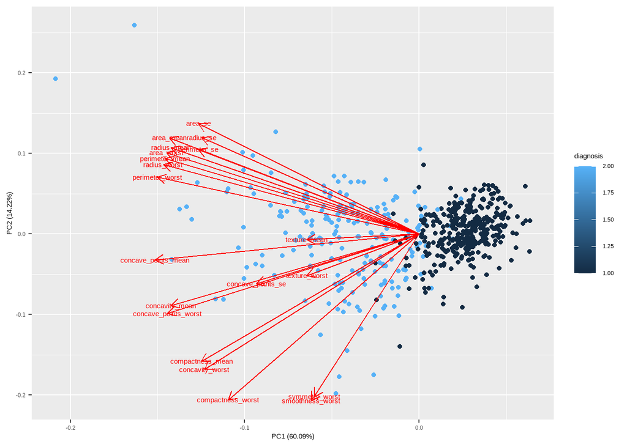

```
##                             PC1         PC2          PC3         PC4
## radius_mean          -0.2572395  0.19390892 -0.037560463  0.23343970
## texture_mean         -0.1166096 -0.01279055 -0.636710264 -0.30566984
## perimeter_mean       -0.2636034  0.16924906 -0.025585172  0.20997515
## area_mean            -0.2589489  0.21576919 -0.021533651  0.18470186
## compactness_mean     -0.2258485 -0.28581441  0.140070450 -0.12932985
## concavity_mean       -0.2574078 -0.16103243  0.108278205 -0.12530510
## concave_points_mean  -0.2738653 -0.05861075  0.093212634  0.01225082
## radius_se            -0.2253555  0.21624766  0.123944533 -0.33395109
## perimeter_se         -0.2288082  0.18967406  0.133242497 -0.36163934
## area_se              -0.2287678  0.24802907  0.099418322 -0.21683484
## concave_points_se    -0.1686513 -0.11158567  0.243935028 -0.47068173
## radius_worst         -0.2652793  0.15599262 -0.065932949  0.22935023
## texture_worst        -0.1164415 -0.09348798 -0.660194522 -0.17368580
## perimeter_worst      -0.2714802  0.12767091 -0.052607456  0.20168141
## area_worst           -0.2618644  0.18219775 -0.053755914  0.18602305
## smoothness_worst     -0.1118995 -0.37435430  0.042676505  0.07553557
## compactness_worst    -0.1980188 -0.37262724 -0.006249628  0.03964861
## concavity_worst      -0.2226963 -0.30393688  0.010077447  0.01288293
## concave_points_worst -0.2610189 -0.17867839  0.032838278  0.11256932
## symmetry_worst       -0.1088131 -0.36524396 -0.025157361  0.22860700
##                               PC5           PC6          PC7         PC8
## radius_mean          -0.144390681  0.0092333376 -0.090357641 -0.10350000
## texture_mean         -0.062550487 -0.0107455752 -0.044537236 -0.18431810
## perimeter_mean       -0.142911718  0.0066983723 -0.063905571 -0.14639154
## area_mean            -0.069327096  0.0229458293 -0.032291161 -0.08320761
## compactness_mean     -0.057290176 -0.0083719852  0.192381448 -0.55733981
## concavity_mean       -0.151523465 -0.0058121632  0.152440809 -0.18302649
## concave_points_mean  -0.066706556  0.1202963346 -0.101287567 -0.39601892
## radius_se             0.327037260 -0.0619597590  0.039685167  0.05418407
## perimeter_se          0.267580839 -0.1176668758  0.090118156  0.01034860
## area_se               0.329266348 -0.0351131397  0.179343989  0.13740427
## concave_points_se    -0.414861618 -0.0012991520 -0.577688748  0.24569863
## radius_worst         -0.007079987  0.0246724285 -0.065440154  0.12460974
## texture_worst         0.044895742  0.0511625325 -0.051731627  0.09838731
## perimeter_worst      -0.022243639  0.0006293253 -0.019020774  0.09320705
## area_worst            0.064651672  0.0442553648 -0.003456585  0.18462350
## smoothness_worst      0.467418199  0.7100857616 -0.177594954  0.05314288
## compactness_worst    -0.063222501 -0.1444318964  0.434171806  0.14281397
## concavity_worst      -0.186232577 -0.0804212075  0.337186494  0.45196194
```

[output cut: 50 more lines]

```
## concavity_mean        0.274823993 -0.0682270647  0.010033173 -1.858007e-02
## concave_points_mean  -0.424607431  0.0221336631 -0.032388128 -5.469773e-04
## radius_se             0.245726101  0.1889928557  0.112454808  1.172279e-02
## perimeter_se          0.037823146 -0.2510361390 -0.011576463 -1.538765e-02
## area_se              -0.339765710  0.0365119117 -0.081373670 -2.334563e-03
## concave_points_se    -0.077240651  0.0215883183 -0.021865141  7.269866e-03
## radius_worst         -0.169401820 -0.4258765364 -0.632305374  1.350417e-01
## texture_worst         0.012942905  0.0093003367  0.006555351  8.932368e-05
## perimeter_worst      -0.254611178  0.7229111878  0.022734003 -8.403676e-02
## area_worst            0.191295999 -0.2309125925  0.454195119 -3.833735e-02
## smoothness_worst     -0.005552512 -0.0052487847  0.009460068 -1.339246e-04
## compactness_worst     0.017400115 -0.0330760293  0.010382478  5.788399e-03
## concavity_worst      -0.194979534  0.0278727598 -0.005373020  4.046599e-03
## concave_points_worst  0.329760140 -0.0214147238  0.046234382 -3.035886e-03
## symmetry_worst       -0.009145332  0.0005511906  0.004954459  8.306582e-04
```

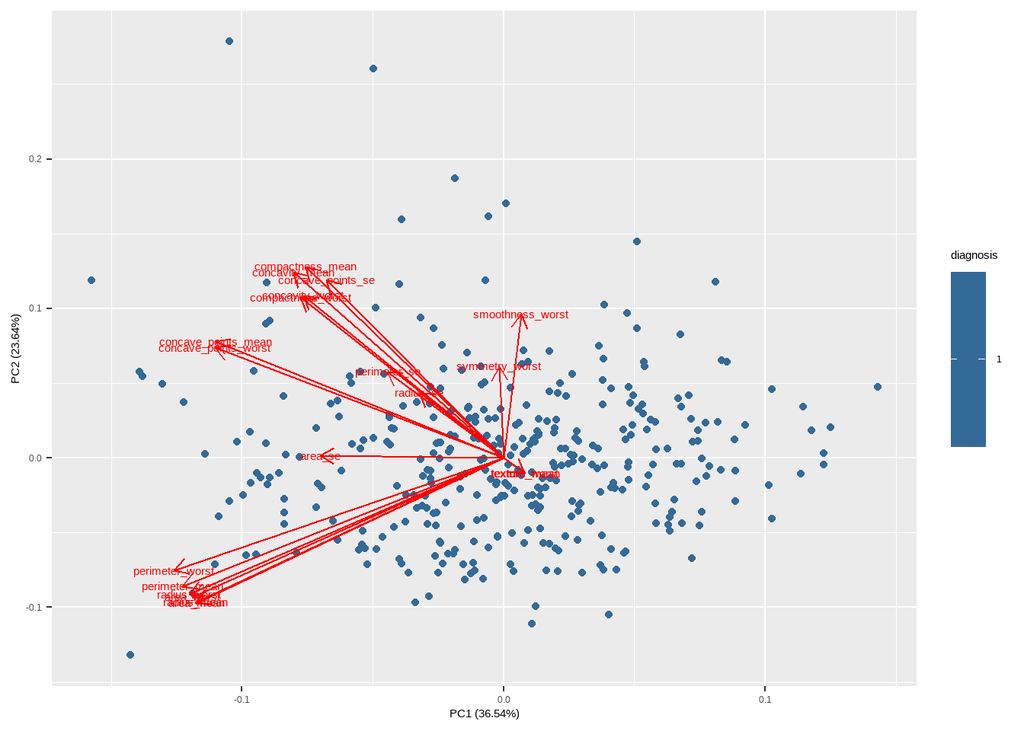

```
##                               PC1          PC2           PC3           PC4
## radius_mean          -0.305689114 -0.250868360 -4.990401e-02 -0.0051882097
## texture_mean          0.021513995 -0.026601830  1.712101e-01  0.6678013242
## perimeter_mean       -0.318804940 -0.223170155 -5.155567e-02 -0.0031759185
## area_mean            -0.305011319 -0.252332135 -3.891878e-02 -0.0092919165
## compactness_mean     -0.196696112  0.332586657 -2.876835e-02  0.0006504456
## concavity_mean       -0.208775837  0.322391645 -8.408305e-04  0.0519381907
## concave_points_mean  -0.286243675  0.202567036  8.864446e-06 -0.0885182637
## radius_se            -0.083662881  0.113815798  5.271851e-01 -0.0931399435
## perimeter_se         -0.115307700  0.149924738  4.834393e-01 -0.0523337042
## area_se              -0.182062179  0.003539812  4.841498e-01 -0.0834788147
## concave_points_se    -0.175627888  0.309608452  1.442852e-01 -0.0462514172
## radius_worst         -0.311789371 -0.236968830 -3.496547e-02  0.0133158295
## texture_worst         0.020636125 -0.026690338  9.089857e-02  0.6885863164
## perimeter_worst      -0.327354617 -0.195998242 -5.062062e-02  0.0282019544
## area_worst           -0.308850637 -0.241794002 -2.578339e-02  0.0095256263
## smoothness_worst      0.017415033  0.249664383 -1.982524e-01 -0.0667853677
## compactness_worst    -0.201651541  0.279281376 -1.950501e-01  0.1379690759
## concavity_worst      -0.199012375  0.282558049 -1.694545e-01  0.1446044482
## concave_points_worst -0.286605943  0.191728129 -1.828629e-01  0.0392595274
## symmetry_worst       -0.004448611  0.159124378 -2.100576e-01  0.0412404154
##                               PC5          PC6         PC7         PC8
## radius_mean           0.002603241 -0.030465121  0.05188515  0.07072197
## texture_mean         -0.007844781 -0.109205125  0.06650720  0.15079102
## perimeter_mean        0.005610906 -0.032300120  0.02500371  0.11388831
## area_mean             0.004807283 -0.013033572  0.04259518  0.03771639
## compactness_mean     -0.036699587 -0.142908577 -0.31899755  0.57783141
## concavity_mean        0.276872961  0.165891385  0.13516405 -0.18044337
## concave_points_mean   0.007612132 -0.341257321  0.27469341  0.21539449
## radius_se            -0.195640490  0.051244021 -0.02211728 -0.13367069
## perimeter_se         -0.133393595  0.142660820 -0.20780425  0.03610531
## area_se              -0.171237388  0.024696011 -0.02209135 -0.15229025
## concave_points_se     0.280017368 -0.107068782  0.46768749  0.07383309
## radius_worst         -0.096791477  0.008848904 -0.03103625 -0.08992317
## texture_worst        -0.093487900 -0.126192926  0.05894261 -0.09472852
## perimeter_worst      -0.081444150  0.051420916 -0.11148851 -0.02648856
## area_worst           -0.084707921  0.024375027 -0.04272599 -0.12630946
## smoothness_worst     -0.509388342 -0.566133115 -0.13358067 -0.38495868
## compactness_worst    -0.004230688  0.186645489 -0.52386220  0.13253552
## concavity_worst       0.195276279  0.334437796 -0.11788568 -0.47714055
```

[output cut: 50 more lines]

```
## concavity_mean       -0.24642342  0.042084873  1.016417e-02  0.0159432069
## concave_points_mean   0.12289571 -0.003410898 -1.094621e-02  0.0016796643
## radius_se             0.04112908 -0.177709359 -8.633463e-02  0.0115494385
## perimeter_se          0.07555723  0.165502697  7.803955e-06 -0.0001648559
## area_se              -0.15664947  0.032518854  8.655202e-02 -0.0085263639
## concave_points_se     0.07854983 -0.013837563  7.859507e-04 -0.0079851673
## radius_worst         -0.18391647  0.552548519  4.554093e-01 -0.2018690942
## texture_worst         0.03659514 -0.011361348 -8.366761e-03  0.0022855225
## perimeter_worst      -0.33009828 -0.719886279  6.453639e-02  0.0544578186
## area_worst            0.54838469  0.120978743 -5.164020e-01  0.1420391894
## smoothness_worst     -0.02487814 -0.002345350 -3.543619e-03 -0.0026611318
## compactness_worst    -0.02047855  0.081499919 -5.236985e-03  0.0039456376
## concavity_worst       0.18346141 -0.040968084 -7.616175e-03 -0.0096132086
## concave_points_worst -0.09976448  0.010179616  1.023205e-02  0.0031681830
## symmetry_worst        0.01010559  0.006071997 -2.214663e-03  0.0005339619
```

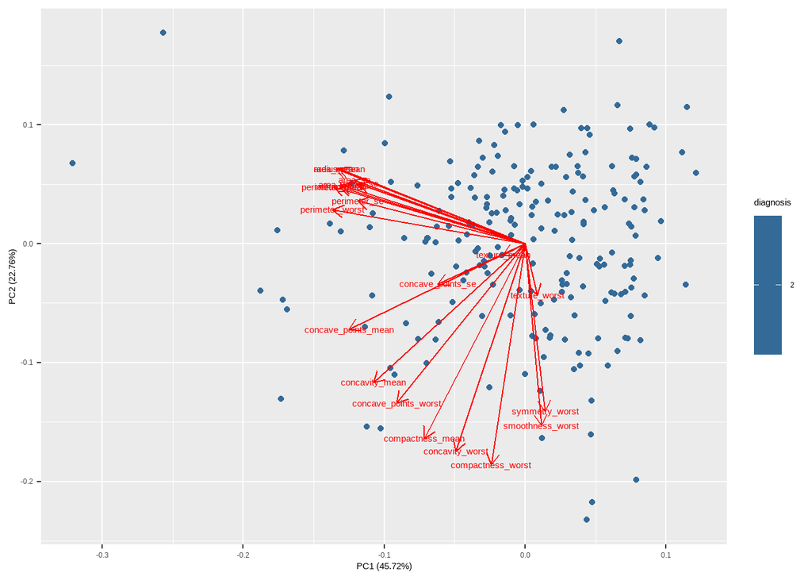

```
##                              PC1         PC2          PC3         PC4
## radius_mean          -0.29640410  0.14176366 -0.073799280  0.17142519
## texture_mean         -0.03548367 -0.02100277 -0.602784566 -0.38138405
## perimeter_mean       -0.30570276  0.10766405 -0.060291292  0.14715200
## area_mean            -0.30154556  0.14158386 -0.068487379  0.14468696
## compactness_mean     -0.16082960 -0.36866962  0.111709257 -0.11484563
## concavity_mean       -0.24218118 -0.26262026  0.087240507 -0.08200026
## concave_points_mean  -0.28110038 -0.16225366  0.087331771  0.03107378
## radius_se            -0.26497090  0.11356320  0.137006233 -0.30661574
## perimeter_se         -0.26724605  0.08129073  0.145861967 -0.35905429
## area_se              -0.27294230  0.12029543  0.084445267 -0.21817997
## concave_points_se    -0.13917627 -0.07630228  0.257151538 -0.50528295
## radius_worst         -0.29565936  0.10772745 -0.142432735  0.22201822
## texture_worst         0.01971691 -0.09716726 -0.645426495 -0.22585308
## perimeter_worst      -0.30720188  0.06475815 -0.125771619  0.17929861
## area_worst           -0.29400293  0.11148077 -0.144090206  0.19511711
## smoothness_worst      0.02592145 -0.34382282 -0.036933975  0.07928921
## compactness_worst    -0.05435070 -0.41821447 -0.058943077  0.01525946
## concavity_worst      -0.11050651 -0.39261693 -0.056281108  0.04395941
## concave_points_worst -0.20486848 -0.30212893  0.018162643  0.14943535
## symmetry_worst        0.03234361 -0.31717185  0.008891073  0.18585617
##                              PC5          PC6           PC7           PC8
## radius_mean          -0.19170602 -0.039128762  3.814277e-02  0.0872933822
## texture_mean         -0.13265614 -0.042202291  3.371890e-02  0.1275100922
## perimeter_mean       -0.19823265 -0.033923215  6.393619e-02  0.1075906361
## area_mean            -0.10533516 -0.007128337  6.344186e-02  0.0717673158
## compactness_mean     -0.07886313 -0.050217494  1.696787e-01  0.1397601362
## concavity_mean       -0.14951261  0.150790007  2.703744e-01  0.3187503946
## concave_points_mean  -0.17135929  0.156082233  3.434343e-05  0.4467841029
## radius_se             0.37020309 -0.015460157  3.649214e-02  0.0002794906
## perimeter_se          0.29036695 -0.072225979  4.362456e-02 -0.0205172270
## area_se               0.40034531  0.014426121  1.387663e-01 -0.0367137704
## concave_points_se    -0.42864634 -0.122193140 -5.137386e-01 -0.2047505727
## radius_worst          0.06144352 -0.031305664 -1.587169e-01 -0.1448296090
## texture_worst         0.07318943  0.001530624 -1.096362e-01  0.0586413438
## perimeter_worst       0.03270106 -0.051707852 -1.186654e-01 -0.1588369928
## area_worst            0.13635743  0.003227807 -1.393687e-01 -0.1904203918
## smoothness_worst      0.37131596  0.614811707 -3.565352e-01  0.1189436508
## compactness_worst     0.06106338 -0.180982735  2.394035e-01 -0.4462713276
## concavity_worst      -0.05330803  0.027432406  3.603813e-01 -0.3396009179
```

[output cut: 50 more lines]

```
## concavity_mean        0.141843209  1.088349e-01  0.001782486 -0.011638915
## concave_points_mean  -0.136776515 -3.082604e-02  0.012479186  0.002479750
## radius_se             0.137110431 -3.338422e-01 -0.103245264  0.034470090
## perimeter_se          0.226397397  3.712828e-01 -0.022917345 -0.032212664
## area_se              -0.467610477 -4.103446e-05  0.086238545 -0.005938127
## concave_points_se    -0.049635133 -2.314442e-02  0.029628111  0.004728543
## radius_worst         -0.200260582  5.033412e-01  0.523650000  0.100941127
## texture_worst        -0.027122494 -1.744725e-02  0.002037523  0.003120003
## perimeter_worst      -0.295808613 -5.915769e-01  0.011550865 -0.064230316
## area_worst            0.469043316  1.115862e-01 -0.449768335 -0.035207155
## smoothness_worst     -0.014637548  1.790479e-03 -0.016317490 -0.001423859
## compactness_worst     0.006951788  4.488599e-02 -0.026039659  0.018094842
## concavity_worst      -0.048763037 -3.648101e-02  0.008765277 -0.003605063
## concave_points_worst  0.060309442  1.181338e-02 -0.032627676  0.001809080
## symmetry_worst        0.006007395 -5.360483e-03 -0.009520253  0.003350561
```

## Final visualizations

1. Final Visualizations that help answering the initial questions:
1. Correlation Plot for All Features and Cancer Severity (diagnosis)

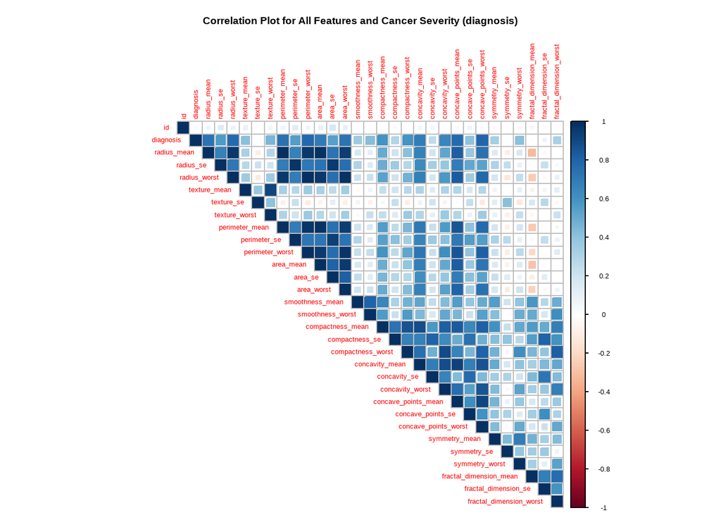

2. Correlation Plot for Size Related Features and Cancer Severity (diagnosis)

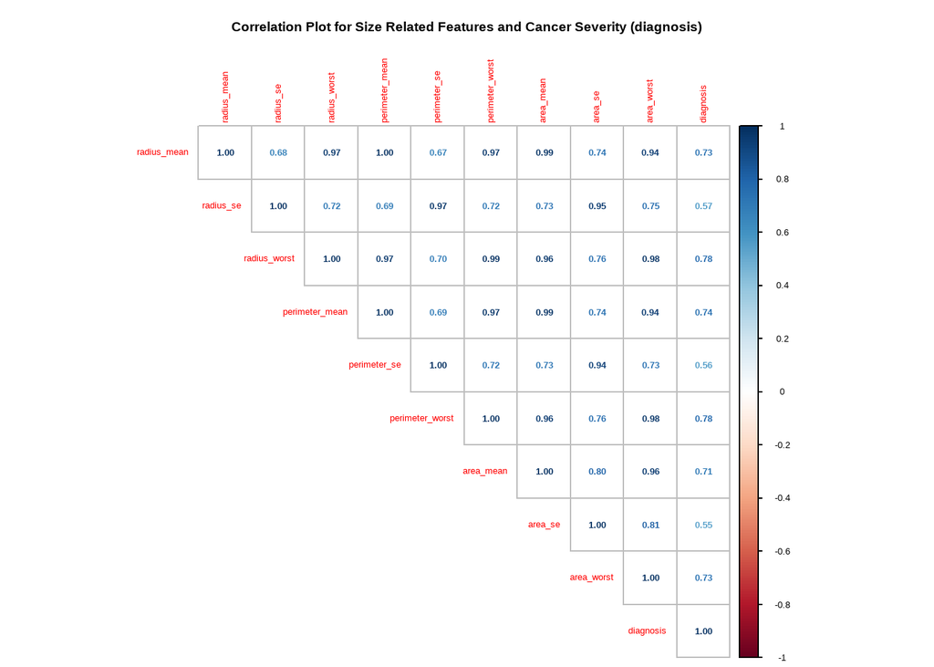

3. PCA1 Plot

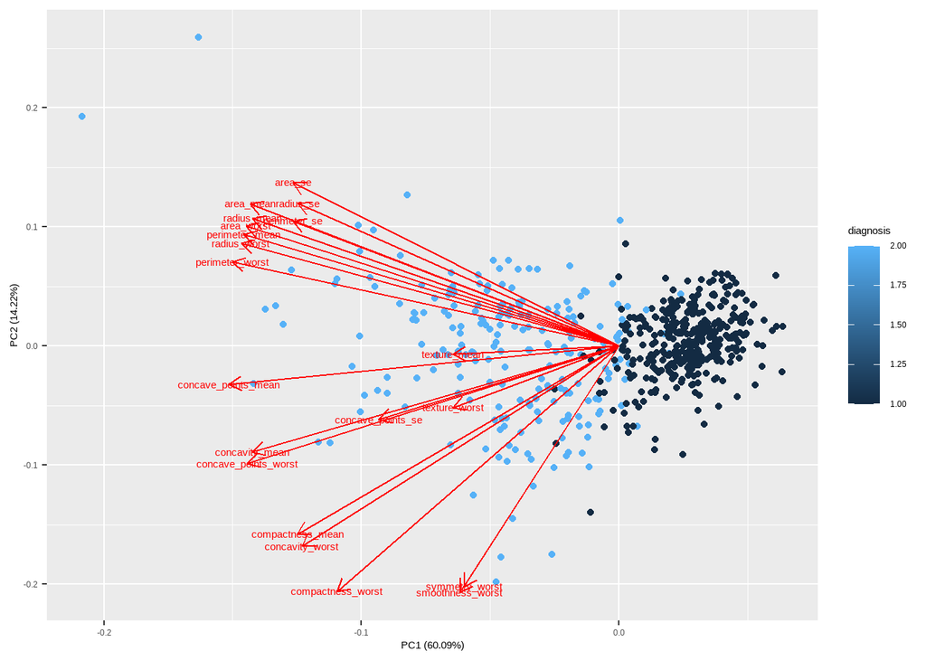

4. PCA2 Plot (with only the most correlated features for all benign severity data)

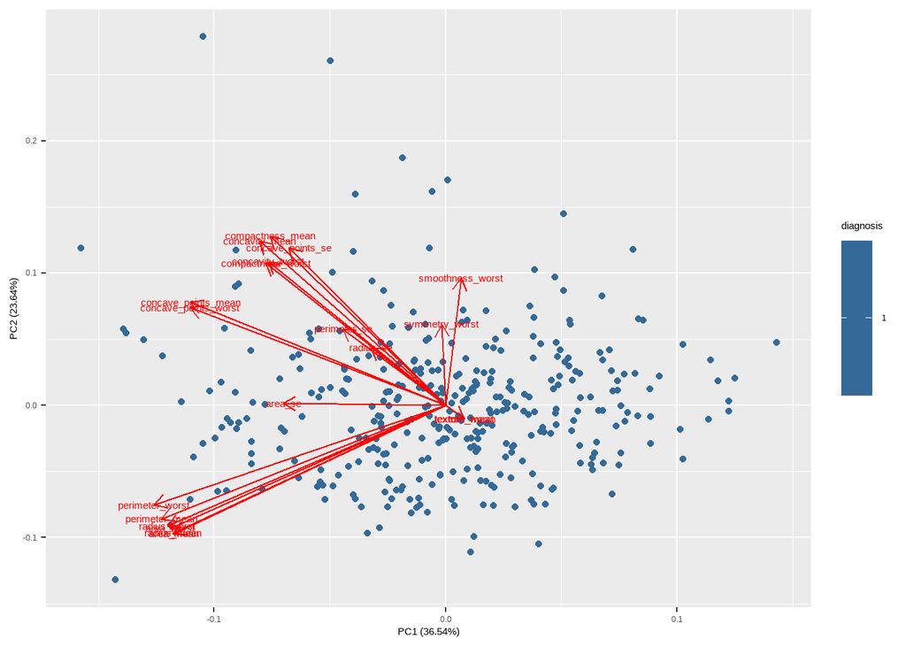

5. PCA3 Plot (with only the most correlated features for all malignany severirty data)

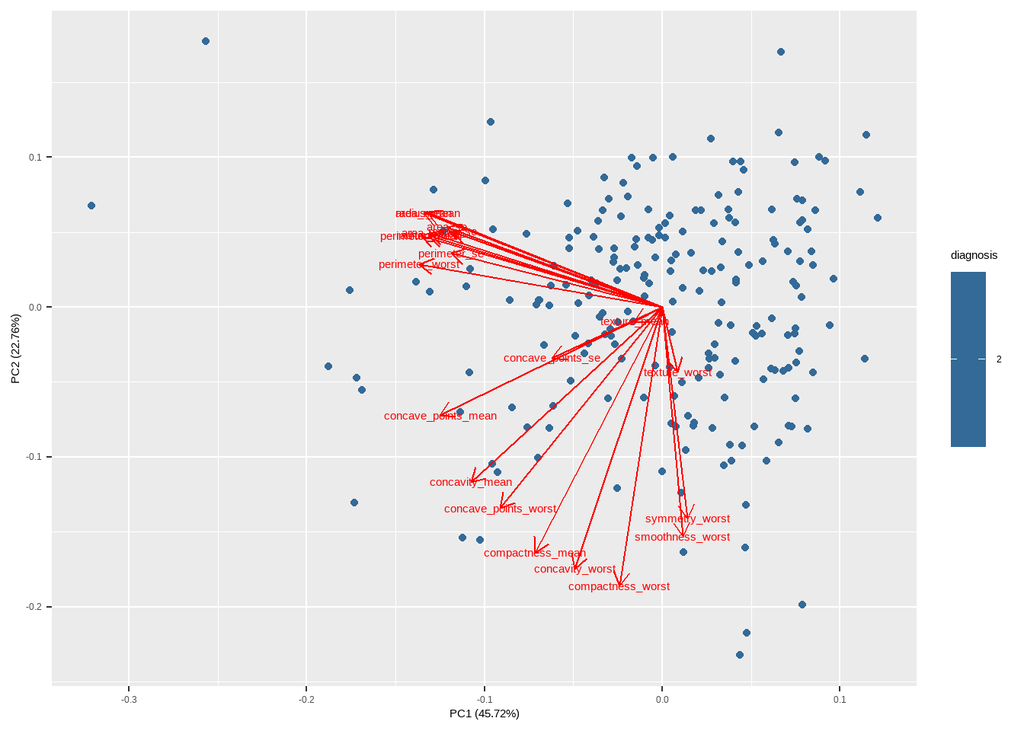

2. Additional Final Visualizations that help gain additional insights and relationships.
1. Correlation Plot for Correlated Features and Cancer Severity (diagnosis)

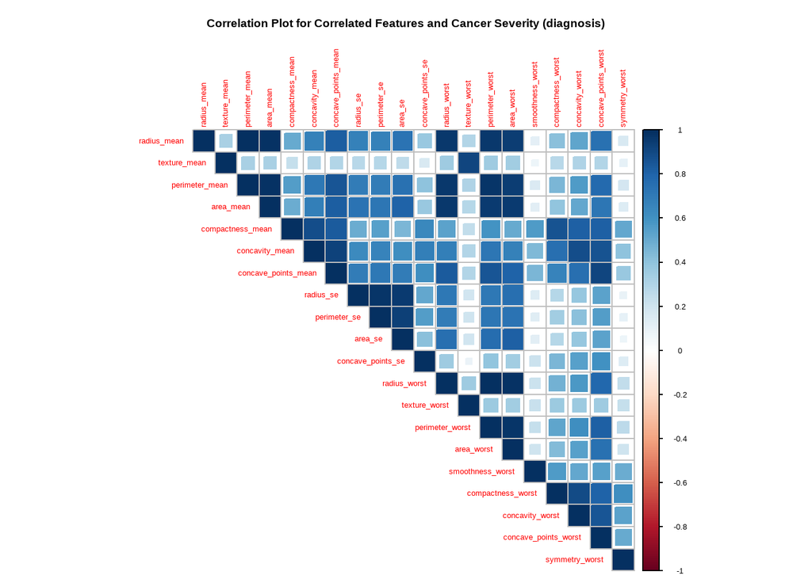

2. Scatterplot of Texture Mean vs Radius Mean

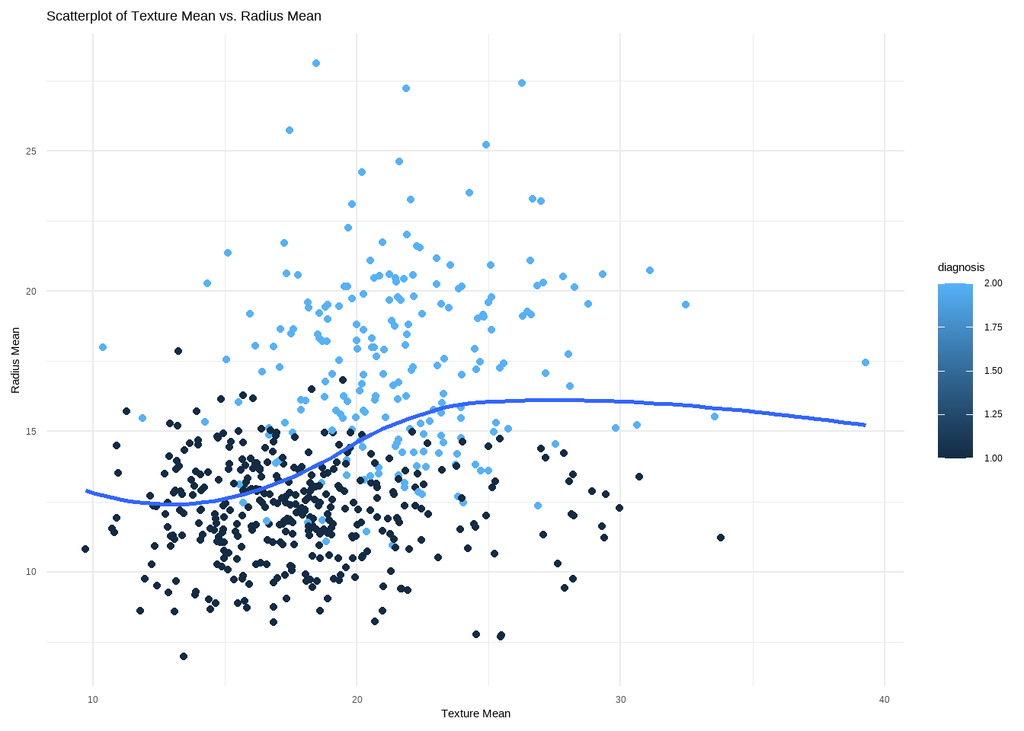

(c) Scatterplot of Concavity Mean vs Compactness Mean

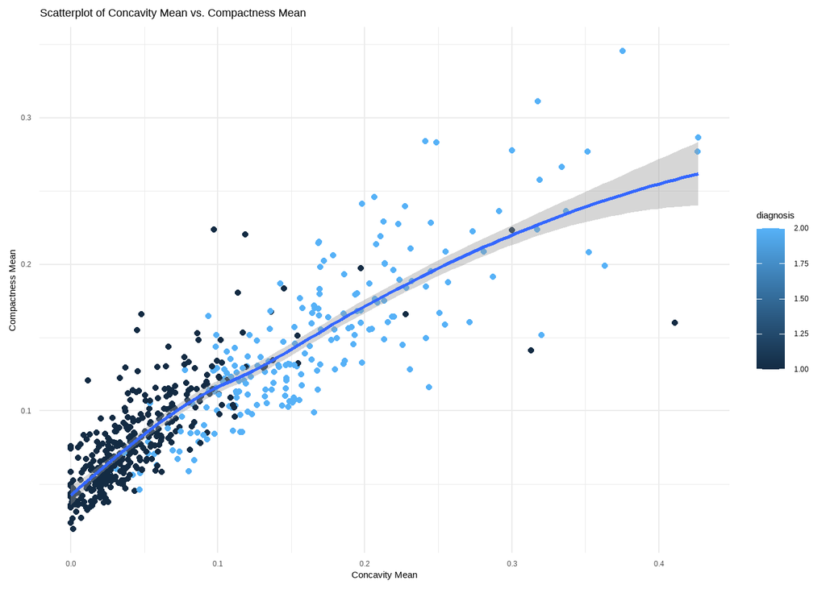

(d) Scatterplot of Perimeter Mean vs Texture Mean

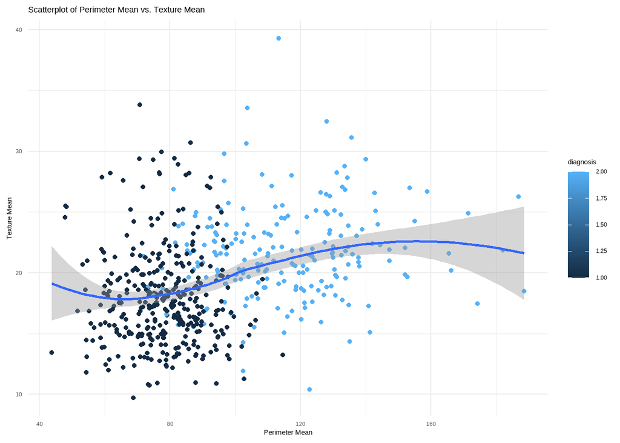

(e) Scatterplot of Radius Mean vs Concavity Mean

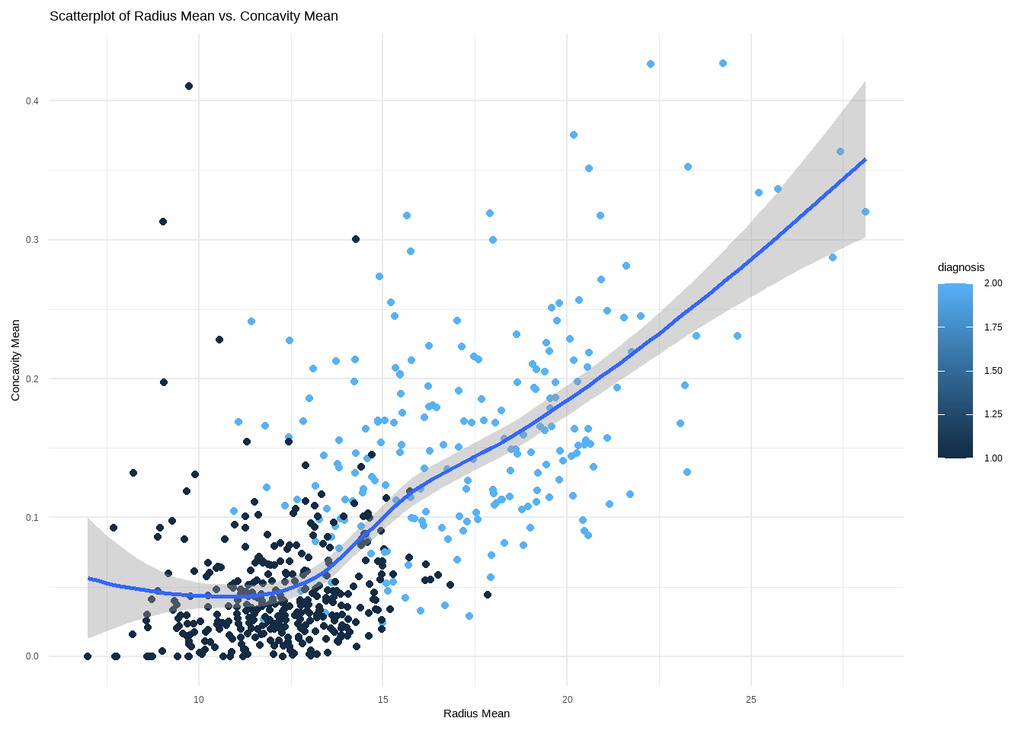

(f) Scatterplot of Radius Mean vs Concave Points Mean

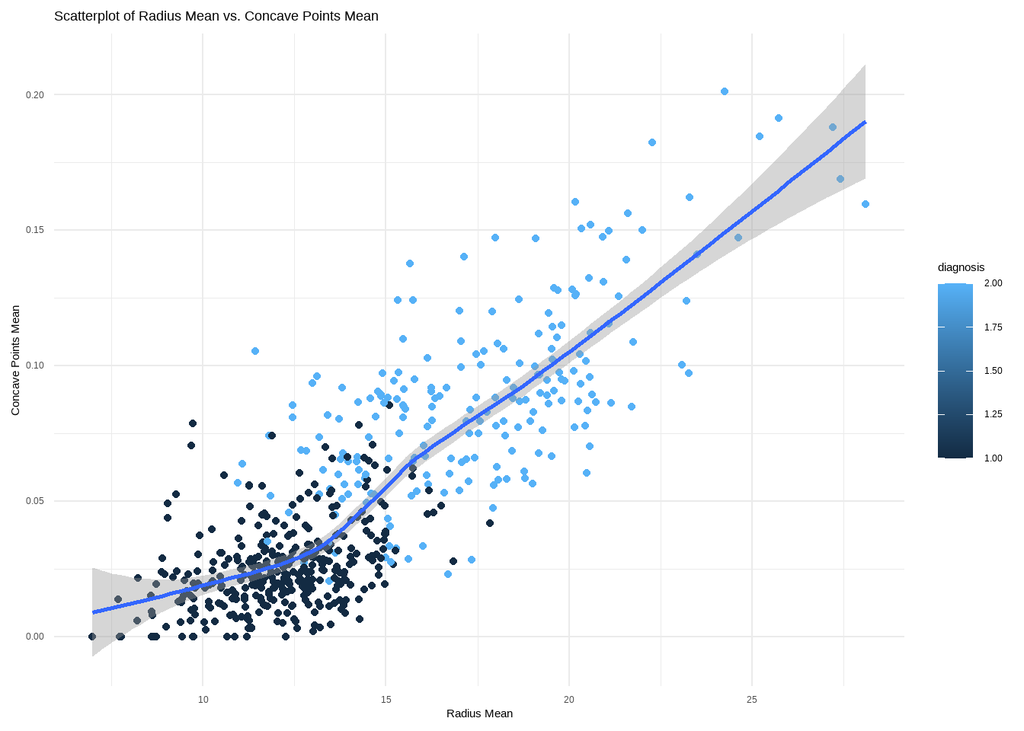

3. List of data used for interpretations but not included
- Summary of all the linear models.
- Correlation values (raw) for better clarity
- Variation distributions for Principal Components for all Principal Component Analyses (rotation).